# STT810 Mini Project

Harish Neelam and Koushik Sai Veerella

### Preferential Attachment Model.

20 Simulations of 15 Nodes

|  | 1 | 2 | 3 | 4 | 5 | 6 | 7 | 8 | 9 | 10 | 11 | 12 | 13 | 14 | 15 | 16 | 17 | 18 | 19 | 20 |
| --- | --- | --- | --- | --- | --- | --- | --- | --- | --- | --- | --- | --- | --- | --- | --- | --- | --- | --- | --- | --- |
| A | 6 | 1 | 10 | 7 | 2 | 6 | 6 | 2 | 4 | 3 | 1 | 10 | 7 | 2 | 2 | 2 | 4 | 4 | 1 | 7 |
| B | 2 | 5 | 1 | 1 | 1 | 3 | 1 | 5 | 3 | 5 | 6 | 1 | 4 | 8 | 6 | 5 | 7 | 4 | 7 | 1 |
| C | 3 | 9 | 3 | 5 | 5 | 2 | 2 | 3 | 1 | 1 | 2 | 1 | 3 | 4 | 1 | 6 | 1 | 1 | 1 | 6 |
| D | 2 | 1 | 1 | 1 | 4 | 1 | 6 | 4 | 3 | 6 | 5 | 1 | 1 | 1 | 5 | 1 | 3 | 2 | 2 | 1 |
| E | 1 | 1 | 1 | 1 | 1 | 2 | 1 | 2 | 1 | 1 | 2 | 1 | 1 | 1 | 1 | 1 | 1 | 2 | 3 | 1 |
| F | 2 | 1 | 1 | 3 | 1 | 1 | 2 | 1 | 5 | 1 | 2 | 2 | 2 | 1 | 3 | 1 | 1 | 3 | 1 | 1 |
| G | 3 | 1 | 2 | 1 | 3 | 2 | 2 | 1 | 1 | 3 | 2 | 1 | 2 | 2 | 1 | 2 | 3 | 3 | 1 | 2 |
| H | 1 | 1 | 1 | 1 | 3 | 2 | 1 | 1 | 2 | 1 | 1 | 2 | 1 | 1 | 1 | 2 | 1 | 1 | 2 | 2 |
| I | 1 | 1 | 1 | 2 | 1 | 1 | 1 | 2 | 1 | 1 | 1 | 2 | 1 | 2 | 1 | 1 | 1 | 2 | 1 | 1 |
| J | 1 | 2 | 1 | 1 | 2 | 1 | 1 | 1 | 2 | 1 | 1 | 2 | 1 | 1 | 1 | 1 | 1 | 1 | 4 | 1 |
| K | 1 | 1 | 1 | 1 | 1 | 2 | 1 | 1 | 1 | 1 | 1 | 1 | 1 | 1 | 1 | 1 | 1 | 1 | 1 | 1 |
| L | 1 | 1 | 2 | 1 | 1 | 2 | 1 | 1 | 1 | 1 | 1 | 1 | 1 | 1 | 2 | 1 | 1 | 1 | 1 | 1 |
| M | 1 | 1 | 1 | 1 | 1 | 1 | 1 | 2 | 1 | 1 | 1 | 1 | 1 | 1 | 1 | 2 | 1 | 1 | 1 | 1 |
| N | 2 | 1 | 1 | 1 | 1 | 1 | 1 | 1 | 1 | 1 | 1 | 1 | 1 | 1 | 1 | 1 | 1 | 1 | 1 | 1 |
| O | 1 | 1 | 1 | 1 | 1 | 1 | 1 | 1 | 1 | 1 | 1 | 1 | 1 | 1 | 1 | 1 | 1 | 1 | 1 | 1 |

- As we see above, the number of edges for 1 to 4 are comparatively more than others. Certainly the first few nodes has more edges compared with others, because a new node is more likely attach to an old node which has more connections. Then the last nodes end up with very few connections. In this simulation, the last nodes ended up with at most 1 edge and 2 edges in very few cases.

#### Affinity Matrix

The Simulations show the number of connections a node has. However, it does not indicate which node is connected to which node. This information can be obtained by an Affinity Matrix. Affinity Matrix is obtained from the Distance matrix. It is nothing but Similarity matrix. It gives the similarity score for every 2 simulations. These similarity measures can be interpreted as the probability that the two points are related. For example, if two data points have coordinates that are close, then their similarity score will be much closer to 1 than two data points with a lot of space between them.Let’s see how this is implemented in this case. The following is the Affinity matrix of 15 nodes:

Affinity Matrix

|  | 1 | 2 | 3 | 4 | 5 | 6 | 7 | 8 | 9 | 10 | 11 | 12 | 13 | 14 | 15 |
| --- | --- | --- | --- | --- | --- | --- | --- | --- | --- | --- | --- | --- | --- | --- | --- |
| A | 1.000 | 0.004 | 0.019 | 0.022 | 0.020 | 0.019 | 0.017 | 0.015 | 0.014 | 0.013 | 0.012 | 0.011 | 0.010 | 0.010 | 0.009 |
| B | 0.004 | 1.000 | 0.016 | 0.020 | 0.019 | 0.017 | 0.015 | 0.013 | 0.012 | 0.011 | 0.011 | 0.010 | 0.009 | 0.009 | 0.008 |
| C | 0.019 | 0.016 | 1.000 | 0.132 | 0.160 | 0.164 | 0.166 | 0.163 | 0.159 | 0.155 | 0.150 | 0.146 | 0.142 | 0.138 | 0.134 |
| D | 0.022 | 0.020 | 0.132 | 1.000 | 0.304 | 0.335 | 0.347 | 0.356 | 0.361 | 0.361 | 0.357 | 0.349 | 0.346 | 0.340 | 0.335 |
| E | 0.020 | 0.019 | 0.160 | 0.304 | 1.000 | 0.448 | 0.480 | 0.503 | 0.520 | 0.523 | 0.522 | 0.521 | 0.519 | 0.515 | 0.512 |
| F | 0.019 | 0.017 | 0.164 | 0.335 | 0.448 | 1.000 | 0.565 | 0.606 | 0.625 | 0.638 | 0.642 | 0.645 | 0.646 | 0.645 | 0.643 |
| G | 0.017 | 0.015 | 0.166 | 0.347 | 0.480 | 0.565 | 1.000 | 0.660 | 0.691 | 0.702 | 0.714 | 0.723 | 0.727 | 0.727 | 0.727 |
| H | 0.015 | 0.013 | 0.163 | 0.356 | 0.503 | 0.606 | 0.660 | 1.000 | 0.752 | 0.771 | 0.787 | 0.798 | 0.803 | 0.808 | 0.811 |
| I | 0.014 | 0.012 | 0.159 | 0.361 | 0.520 | 0.625 | 0.691 | 0.752 | 1.000 | 0.814 | 0.833 | 0.846 | 0.856 | 0.863 | 0.868 |
| J | 0.013 | 0.011 | 0.155 | 0.361 | 0.523 | 0.638 | 0.702 | 0.771 | 0.814 | 1.000 | 0.861 | 0.877 | 0.888 | 0.896 | 0.904 |
| K | 0.012 | 0.011 | 0.150 | 0.357 | 0.522 | 0.642 | 0.714 | 0.787 | 0.833 | 0.861 | 1.000 | 0.903 | 0.915 | 0.926 | 0.933 |
| L | 0.011 | 0.010 | 0.146 | 0.349 | 0.521 | 0.645 | 0.723 | 0.798 | 0.846 | 0.877 | 0.903 | 1.000 | 0.935 | 0.947 | 0.956 |
| M | 0.010 | 0.009 | 0.142 | 0.346 | 0.519 | 0.646 | 0.727 | 0.803 | 0.856 | 0.888 | 0.915 | 0.935 | 1.000 | 0.963 | 0.973 |
| N | 0.010 | 0.009 | 0.138 | 0.340 | 0.515 | 0.645 | 0.727 | 0.808 | 0.863 | 0.896 | 0.926 | 0.947 | 0.963 | 1.000 | 0.989 |
| O | 0.009 | 0.008 | 0.134 | 0.335 | 0.512 | 0.643 | 0.727 | 0.811 | 0.868 | 0.904 | 0.933 | 0.956 | 0.973 | 0.989 | 1.000 |

- The following shows the number of times the nodes are connected to each other in 10000 simulations(Adjacency matrix for 10000 simulations, describing the probalities of connections.

No.of times a node is connected to other in 10000 simulations.

|  | 1 | 2 | 3 | 4 | 5 | 6 | 7 | 8 | 9 | 10 | 11 | 12 | 13 | 14 | 15 |
| --- | --- | --- | --- | --- | --- | --- | --- | --- | --- | --- | --- | --- | --- | --- | --- |
| A | 0 | 10000 | 5030 | 3781 | 3091 | 2688 | 2413 | 2232 | 2057 | 1886 | 1831 | 1750 | 1676 | 1570 | 1579 |
| B | 10000 | 0 | 4970 | 3733 | 3119 | 2666 | 2416 | 2340 | 2109 | 1940 | 1833 | 1755 | 1718 | 1620 | 1551 |
| C | 5030 | 4970 | 0 | 2486 | 2120 | 1877 | 1697 | 1473 | 1446 | 1305 | 1257 | 1201 | 1145 | 1099 | 1080 |
| D | 3781 | 3733 | 2486 | 0 | 1670 | 1495 | 1349 | 1206 | 1080 | 1067 | 989 | 990 | 909 | 880 | 794 |
| E | 3091 | 3119 | 2120 | 1670 | 0 | 1274 | 1101 | 1032 | 963 | 918 | 840 | 824 | 781 | 710 | 718 |
| F | 2688 | 2666 | 1877 | 1495 | 1274 | 0 | 1024 | 892 | 847 | 837 | 774 | 688 | 670 | 657 | 613 |
| G | 2413 | 2416 | 1697 | 1349 | 1101 | 1024 | 0 | 825 | 795 | 742 | 729 | 667 | 623 | 618 | 560 |
| H | 2232 | 2340 | 1473 | 1206 | 1032 | 892 | 825 | 0 | 703 | 657 | 606 | 582 | 543 | 563 | 530 |
| I | 2057 | 2109 | 1446 | 1080 | 963 | 847 | 795 | 703 | 0 | 648 | 584 | 530 | 487 | 498 | 457 |
| J | 1886 | 1940 | 1305 | 1067 | 918 | 837 | 742 | 657 | 648 | 0 | 557 | 514 | 510 | 456 | 466 |
| K | 1831 | 1833 | 1257 | 989 | 840 | 774 | 729 | 606 | 584 | 557 | 0 | 499 | 488 | 462 | 414 |
| L | 1750 | 1755 | 1201 | 990 | 824 | 688 | 667 | 582 | 530 | 514 | 499 | 0 | 450 | 442 | 413 |
| M | 1676 | 1718 | 1145 | 909 | 781 | 670 | 623 | 543 | 487 | 510 | 488 | 450 | 0 | 425 | 434 |
| N | 1570 | 1620 | 1099 | 880 | 710 | 657 | 618 | 563 | 498 | 456 | 462 | 442 | 425 | 0 | 391 |
| O | 1579 | 1551 | 1080 | 794 | 718 | 613 | 560 | 530 | 457 | 466 | 414 | 413 | 434 | 391 | 0 |

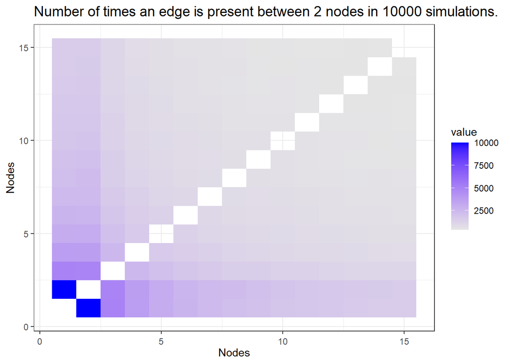

- The Following is the Affinity Matrix, in the below figure we can easily tell the closely related node to any node by just considering the colors.

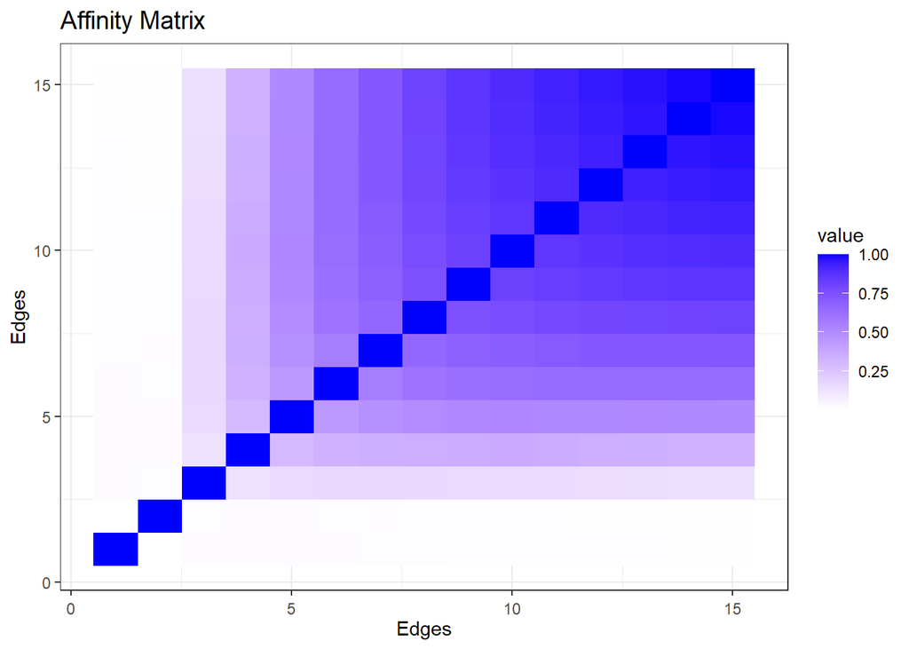

- The Affinity matrix is obtained from the distance matrix. The distance matrix calculates the Euclidean distance for every 2 simulations and gives the result. Then this Distance matrix is used to find Similarity matrix. The Similarity matrix is the opposite of Distance matrix. If the distance between 2 set of data points is 0, it tells that those are related or close to each other. In similarity matrix, the value will be 1, for those which are similar. We used the below formula to calculate the Affinity matrix from Distance matrix.

$$Affinity \;Matrix \;=\exp(-\beta * Distance\;Matrix^2)\;\;;where \;\;\beta=\frac{1}{2\sigma^2}$$

The Beta value is defined such that we get 1 as diagonal elements. It will be easier to analyse similarity in this case. The Affinity matrix can also be calculated with r-package SNFtool. It takes number of neighbors, hyperparameter and distance matrix as inputs and give affinity matrix as output. Even though the values from both these methods are different, they convey the same message i.e; same similarity.

#### Number of edges vs Edge number.

- In every simulation, the number edges for a node are different.

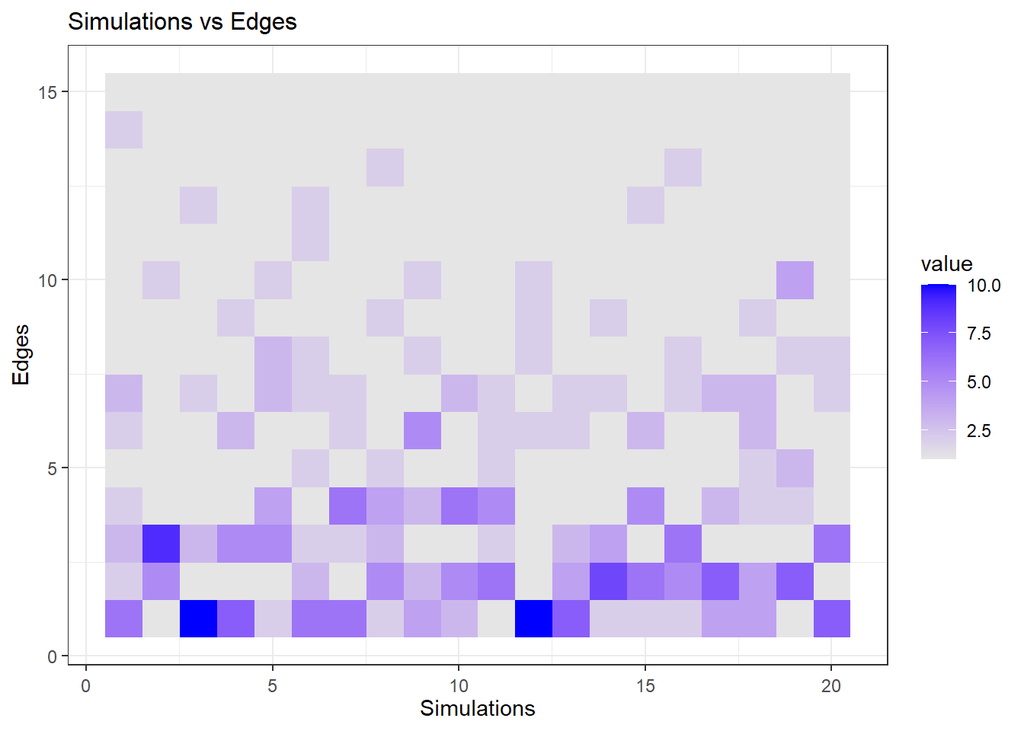

- Here, the edge number 8 is observed whether to which node it is connected.

| Edge_8_to_which_node | Freq |
| --- | --- |
| 1 | 1051 |
| 2 | 5228 |
| 3 | 3298 |
| 4 | 419 |
| 5 | 4 |

#### Edge Statistics

- We can try to look into the edges and nodes, to get new insights.

Probability of k node having n edges.

|  | 1 | 2 | 3 | 4 | 5 | 6 | 7 | 8 | 9 | 10 | 11 | 12 | 13 | 14 | 15 |
| --- | --- | --- | --- | --- | --- | --- | --- | --- | --- | --- | --- | --- | --- | --- | --- |
| A | 0.15 | 0.15 | 0.16 | 0.14 | 0.12 | 0.10 | 0.08 | 0.05 | 0.03 | 0.02 | 0.01 | 0 | 0 | 0 | 0 |
| B | 0.15 | 0.15 | 0.16 | 0.13 | 0.12 | 0.10 | 0.07 | 0.05 | 0.04 | 0.02 | 0.01 | 0 | 0 | 0 | 0 |
| C | 0.31 | 0.23 | 0.17 | 0.12 | 0.08 | 0.05 | 0.03 | 0.01 | 0.01 | 0.00 | 0.00 | 0 | 0 | 0 | 0 |
| D | 0.41 | 0.26 | 0.16 | 0.09 | 0.05 | 0.02 | 0.01 | 0.00 | 0.00 | 0.00 | 0.00 | 0 | 0 | 0 | 0 |
| E | 0.49 | 0.27 | 0.13 | 0.06 | 0.03 | 0.01 | 0.00 | 0.00 | 0.00 | 0.00 | 0.00 | 0 | 0 | 0 | 0 |
| F | 0.57 | 0.26 | 0.11 | 0.04 | 0.01 | 0.00 | 0.00 | 0.00 | 0.00 | 0.00 | 0.00 | 0 | 0 | 0 | 0 |
| G | 0.63 | 0.23 | 0.09 | 0.03 | 0.01 | 0.00 | 0.00 | 0.00 | 0.00 | 0.00 | 0.00 | 0 | 0 | 0 | 0 |
| H | 0.69 | 0.22 | 0.06 | 0.02 | 0.00 | 0.00 | 0.00 | 0.00 | 0.00 | 0.00 | 0.00 | 0 | 0 | 0 | 0 |
| I | 0.75 | 0.20 | 0.04 | 0.01 | 0.00 | 0.00 | 0.00 | 0.00 | 0.00 | 0.00 | 0.00 | 0 | 0 | 0 | 0 |
| J | 0.79 | 0.17 | 0.03 | 0.00 | 0.00 | 0.00 | 0.00 | 0.00 | 0.00 | 0.00 | 0.00 | 0 | 0 | 0 | 0 |
| K | 0.84 | 0.14 | 0.02 | 0.00 | 0.00 | 0.00 | 0.00 | 0.00 | 0.00 | 0.00 | 0.00 | 0 | 0 | 0 | 0 |
| L | 0.88 | 0.11 | 0.01 | 0.00 | 0.00 | 0.00 | 0.00 | 0.00 | 0.00 | 0.00 | 0.00 | 0 | 0 | 0 | 0 |
| M | 0.92 | 0.08 | 0.00 | 0.00 | 0.00 | 0.00 | 0.00 | 0.00 | 0.00 | 0.00 | 0.00 | 0 | 0 | 0 | 0 |
| N | 0.96 | 0.04 | 0.00 | 0.00 | 0.00 | 0.00 | 0.00 | 0.00 | 0.00 | 0.00 | 0.00 | 0 | 0 | 0 | 0 |
| O | 1.00 | 0.00 | 0.00 | 0.00 | 0.00 | 0.00 | 0.00 | 0.00 | 0.00 | 0.00 | 0.00 | 0 | 0 | 0 | 0 |

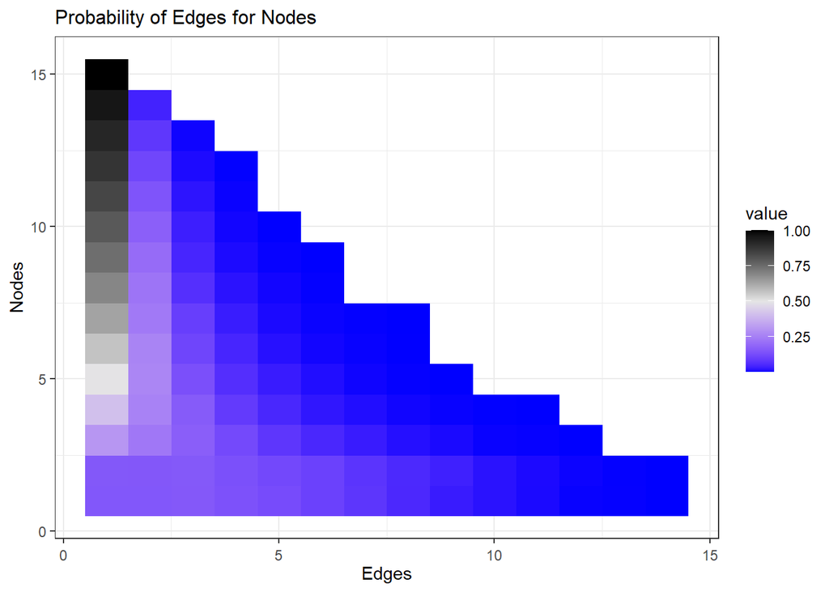

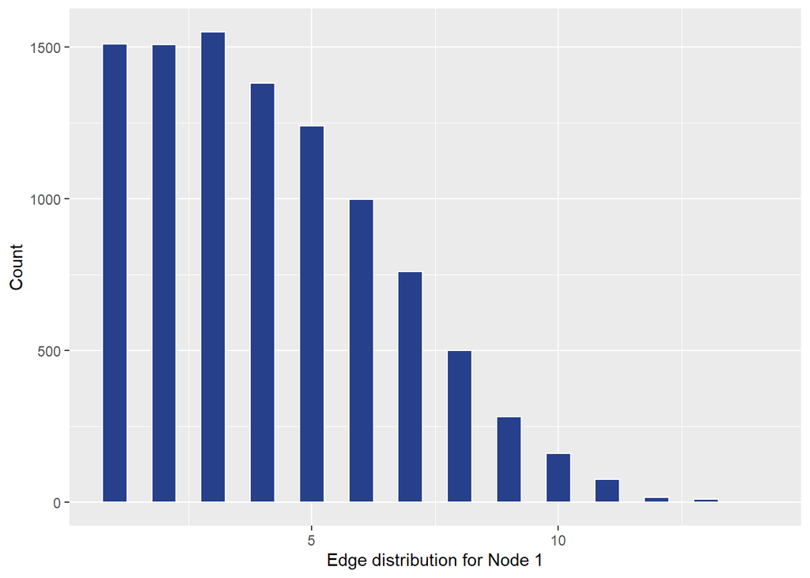

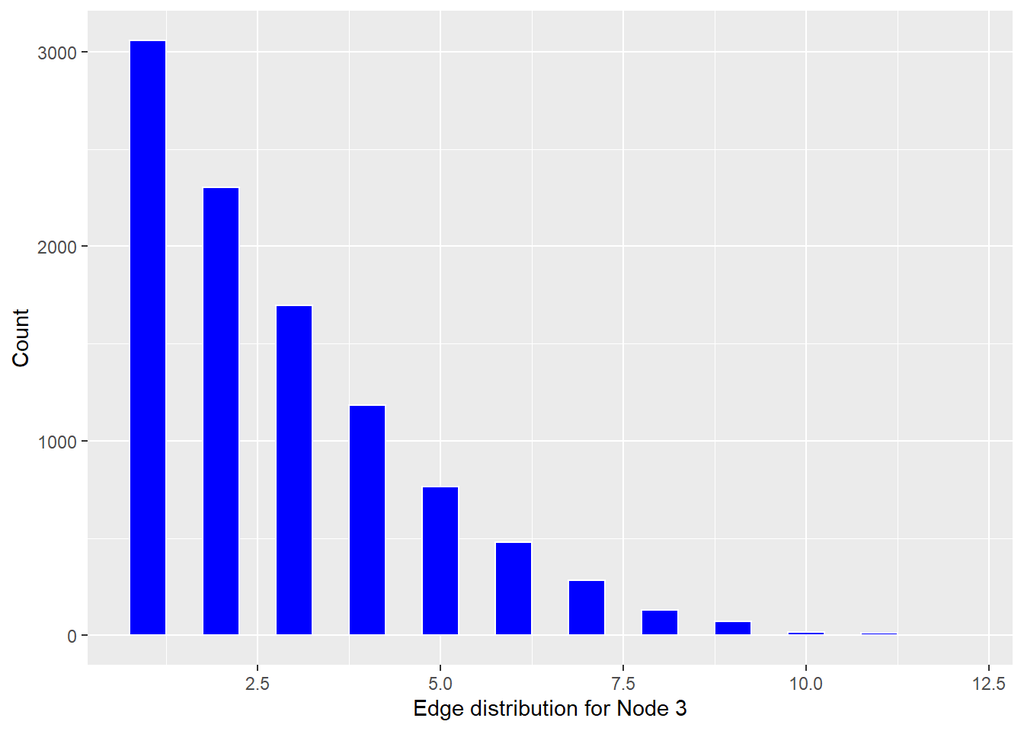

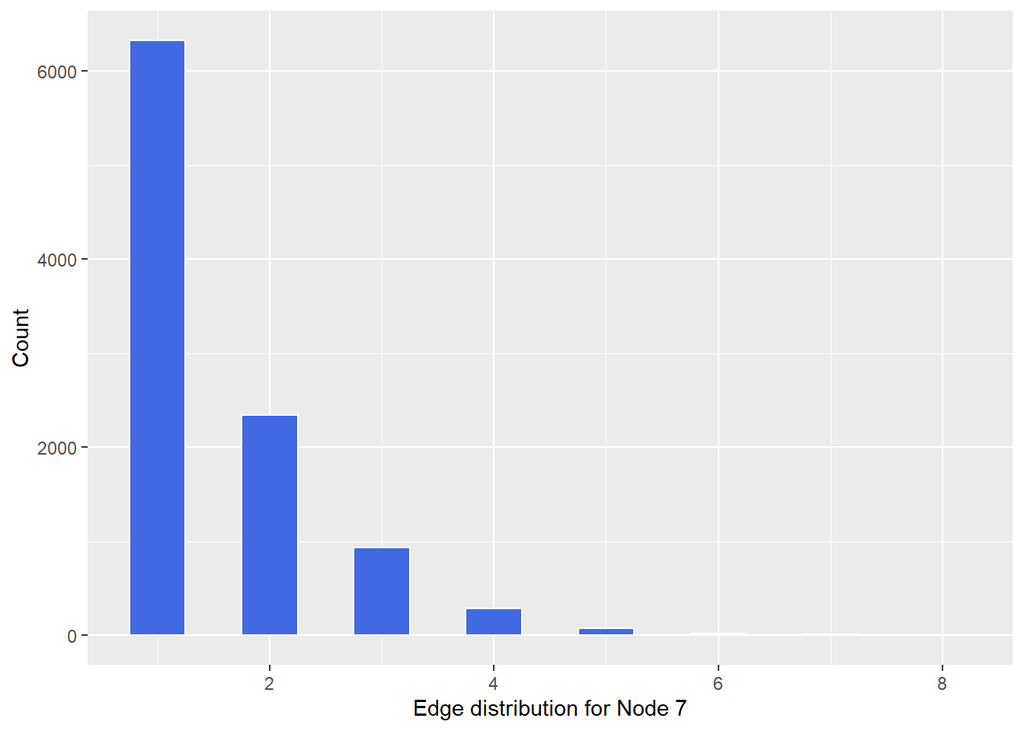

- We can say that these follow exponential distribution. The number of edges a node has is following exponential distribution. We can find the rate of distribution. The rate of Node 1,3,5,7,9 and Node 11 is as follows:

```
## 0.2404771 0.3547861 0.5218934 0.6427148 0.7573463 0.8429571
```

- This shows that the rate of distribution when nodes are increasing will increase to 1 eventually. The mean also will slowly declines to 1.

#### 100 Nodes.

- We have repeated the above experiment for 100 nodes.
- In every simulation of 100 nodes, the number edges for a node are different.

20 Simulations of first 20 Nodes in 100.

|  | 1 | 2 | 3 | 4 | 5 | 6 | 7 | 8 | 9 | 10 | 11 | 12 | 13 | 14 | 15 | 16 | 17 | 18 | 19 | 20 |
| --- | --- | --- | --- | --- | --- | --- | --- | --- | --- | --- | --- | --- | --- | --- | --- | --- | --- | --- | --- | --- |
| A | 9 | 2 | 27 | 28 | 10 | 5 | 11 | 14 | 21 | 2 | 1 | 10 | 6 | 26 | 18 | 16 | 4 | 17 | 1 | 10 |
| B | 9 | 11 | 1 | 7 | 26 | 17 | 2 | 10 | 21 | 1 | 16 | 11 | 4 | 3 | 2 | 22 | 15 | 5 | 7 | 32 |
| C | 5 | 17 | 1 | 5 | 1 | 16 | 2 | 11 | 1 | 36 | 13 | 2 | 2 | 9 | 3 | 1 | 10 | 3 | 20 | 1 |
| D | 2 | 21 | 3 | 1 | 6 | 2 | 3 | 1 | 3 | 6 | 7 | 1 | 7 | 7 | 3 | 6 | 6 | 1 | 9 | 2 |
| E | 18 | 3 | 8 | 4 | 7 | 1 | 15 | 3 | 4 | 10 | 14 | 4 | 12 | 8 | 4 | 1 | 19 | 7 | 3 | 5 |
| F | 1 | 3 | 2 | 2 | 1 | 1 | 1 | 10 | 8 | 2 | 5 | 7 | 15 | 15 | 2 | 1 | 2 | 7 | 12 | 1 |
| G | 2 | 2 | 5 | 5 | 3 | 1 | 1 | 3 | 2 | 4 | 1 | 2 | 2 | 3 | 10 | 1 | 2 | 6 | 2 | 2 |
| H | 7 | 2 | 1 | 4 | 8 | 1 | 2 | 2 | 1 | 3 | 7 | 11 | 2 | 4 | 5 | 2 | 8 | 13 | 1 | 3 |
| I | 1 | 2 | 8 | 2 | 1 | 3 | 2 | 1 | 1 | 1 | 2 | 1 | 5 | 1 | 4 | 3 | 1 | 4 | 4 | 3 |
| J | 11 | 4 | 1 | 3 | 4 | 1 | 1 | 8 | 3 | 3 | 2 | 1 | 1 | 2 | 8 | 6 | 1 | 10 | 1 | 3 |
| K | 4 | 1 | 3 | 2 | 3 | 7 | 3 | 2 | 1 | 3 | 1 | 5 | 2 | 4 | 3 | 3 | 5 | 6 | 1 | 6 |
| L | 2 | 2 | 6 | 1 | 1 | 1 | 10 | 1 | 2 | 4 | 1 | 16 | 4 | 1 | 5 | 2 | 2 | 2 | 1 | 3 |
| M | 4 | 4 | 3 | 1 | 5 | 5 | 7 | 2 | 1 | 1 | 1 | 2 | 1 | 1 | 2 | 3 | 2 | 1 | 1 | 1 |
| N | 5 | 8 | 3 | 3 | 2 | 2 | 3 | 2 | 1 | 4 | 4 | 2 | 4 | 1 | 2 | 7 | 1 | 2 | 2 | 6 |
| O | 5 | 2 | 5 | 3 | 2 | 3 | 1 | 1 | 6 | 1 | 1 | 4 | 2 | 1 | 2 | 2 | 3 | 2 | 3 | 3 |
| P | 2 | 4 | 5 | 1 | 1 | 4 | 7 | 12 | 1 | 1 | 3 | 1 | 2 | 6 | 2 | 1 | 1 | 1 | 3 | 1 |
| Q | 2 | 2 | 2 | 3 | 2 | 4 | 1 | 1 | 1 | 2 | 1 | 1 | 1 | 1 | 5 | 1 | 2 | 1 | 1 | 1 |
| R | 2 | 6 | 2 | 3 | 1 | 1 | 4 | 2 | 3 | 4 | 4 | 1 | 1 | 1 | 1 | 1 | 2 | 1 | 5 | 3 |
| S | 2 | 1 | 4 | 6 | 1 | 1 | 2 | 1 | 2 | 1 | 1 | 1 | 1 | 2 | 3 | 1 | 2 | 1 | 2 | 1 |
| T | 1 | 1 | 2 | 1 | 2 | 5 | 1 | 1 | 1 | 1 | 3 | 3 | 1 | 2 | 1 | 6 | 1 | 1 | 7 | 1 |

- The Below figure is the matrix of 25 nodes with 25 simulations.

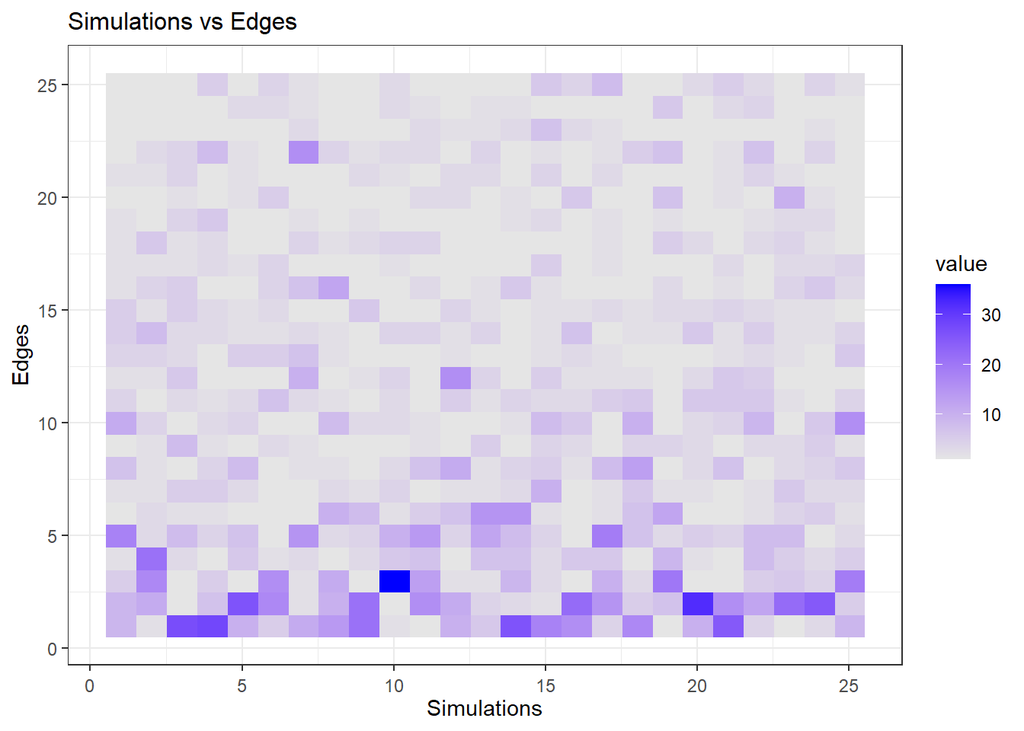

- We can see that the probabilty distribution changed a little bit from earlier.
- Here, The probability for last few nodes to have only one edge is 1 . In the same way, the probability of many nodes having more than 5 edges is 0. In the previous case, the probability was close to 0.5. This decreased when number of nodes were increased.

Probability of having n edges for k node.

|  | 1 | 2 | 3 | 4 | 5 | 6 | 7 | 8 | 9 | 10 | 11 | 12 | 13 | 14 | 15 | 16 | 17 | 18 | 19 | 20 |
| --- | --- | --- | --- | --- | --- | --- | --- | --- | --- | --- | --- | --- | --- | --- | --- | --- | --- | --- | --- | --- |
| A | 0.06 | 0.05 | 0.05 | 0.07 | 0.06 | 0.05 | 0.04 | 0.06 | 0.05 | 0.06 | 0.05 | 0.03 | 0.03 | 0.04 | 0.04 | 0.03 | 0.03 | 0.03 | 0.02 | 0.01 |
| B | 0.06 | 0.04 | 0.07 | 0.06 | 0.06 | 0.06 | 0.04 | 0.05 | 0.05 | 0.04 | 0.05 | 0.04 | 0.03 | 0.03 | 0.03 | 0.04 | 0.03 | 0.02 | 0.03 | 0.02 |
| C | 0.12 | 0.09 | 0.09 | 0.09 | 0.08 | 0.07 | 0.06 | 0.04 | 0.05 | 0.04 | 0.04 | 0.03 | 0.03 | 0.03 | 0.02 | 0.02 | 0.01 | 0.01 | 0.01 | 0.01 |
| D | 0.17 | 0.14 | 0.13 | 0.08 | 0.08 | 0.07 | 0.06 | 0.04 | 0.05 | 0.03 | 0.03 | 0.03 | 0.01 | 0.02 | 0.01 | 0.01 | 0.00 | 0.01 | 0.01 | 0.00 |
| E | 0.18 | 0.14 | 0.12 | 0.11 | 0.07 | 0.06 | 0.06 | 0.06 | 0.05 | 0.04 | 0.02 | 0.02 | 0.01 | 0.01 | 0.01 | 0.01 | 0.00 | 0.01 | 0.00 | 0.00 |
| F | 0.21 | 0.16 | 0.13 | 0.12 | 0.08 | 0.07 | 0.06 | 0.05 | 0.03 | 0.02 | 0.02 | 0.01 | 0.02 | 0.01 | 0.01 | 0.00 | 0.00 | 0.00 | 0.00 | 0.00 |
| G | 0.22 | 0.19 | 0.14 | 0.10 | 0.09 | 0.07 | 0.04 | 0.04 | 0.02 | 0.03 | 0.01 | 0.01 | 0.01 | 0.01 | 0.01 | 0.00 | 0.00 | 0.00 | 0.00 | 0.00 |
| H | 0.24 | 0.21 | 0.14 | 0.10 | 0.09 | 0.06 | 0.05 | 0.04 | 0.02 | 0.01 | 0.01 | 0.00 | 0.01 | 0.00 | 0.01 | 0.00 | 0.00 | 0.00 | 0.00 | 0.00 |
| I | 0.28 | 0.20 | 0.15 | 0.12 | 0.09 | 0.05 | 0.03 | 0.03 | 0.02 | 0.01 | 0.01 | 0.01 | 0.00 | 0.00 | 0.00 | 0.00 | 0.00 | 0.00 | 0.00 | 0.00 |
| J | 0.31 | 0.18 | 0.13 | 0.11 | 0.07 | 0.06 | 0.04 | 0.03 | 0.03 | 0.01 | 0.01 | 0.00 | 0.00 | 0.00 | 0.00 | 0.00 | 0.00 | 0.00 | 0.00 | 0.00 |
| K | 0.31 | 0.21 | 0.17 | 0.10 | 0.06 | 0.06 | 0.04 | 0.02 | 0.01 | 0.01 | 0.01 | 0.00 | 0.01 | 0.00 | 0.00 | 0.00 | 0.00 | 0.00 | 0.00 | 0.00 |
| L | 0.32 | 0.23 | 0.16 | 0.11 | 0.07 | 0.03 | 0.03 | 0.02 | 0.01 | 0.01 | 0.00 | 0.00 | 0.00 | 0.00 | 0.00 | 0.00 | 0.00 | 0.00 | 0.00 | 0.00 |
| M | 0.31 | 0.20 | 0.17 | 0.11 | 0.06 | 0.05 | 0.03 | 0.02 | 0.01 | 0.02 | 0.00 | 0.01 | 0.00 | 0.00 | 0.00 | 0.00 | 0.00 | 0.00 | 0.00 | 0.00 |
| N | 0.35 | 0.24 | 0.15 | 0.10 | 0.06 | 0.04 | 0.03 | 0.01 | 0.01 | 0.01 | 0.00 | 0.00 | 0.00 | 0.00 | 0.00 | 0.00 | 0.00 | 0.00 | 0.00 | 0.00 |
| O | 0.36 | 0.25 | 0.16 | 0.08 | 0.07 | 0.03 | 0.02 | 0.01 | 0.00 | 0.00 | 0.00 | 0.00 | 0.00 | 0.00 | 0.00 | 0.00 | 0.00 | 0.00 | 0.00 | 0.00 |
| P | 0.37 | 0.25 | 0.16 | 0.09 | 0.04 | 0.03 | 0.02 | 0.02 | 0.01 | 0.01 | 0.00 | 0.00 | 0.00 | 0.00 | 0.00 | 0.00 | 0.00 | 0.00 | 0.00 | 0.00 |
| Q | 0.39 | 0.24 | 0.14 | 0.10 | 0.06 | 0.02 | 0.01 | 0.02 | 0.01 | 0.00 | 0.00 | 0.00 | 0.00 | 0.00 | 0.00 | 0.00 | 0.00 | 0.00 | 0.00 | 0.00 |
| R | 0.43 | 0.23 | 0.13 | 0.08 | 0.06 | 0.03 | 0.03 | 0.01 | 0.01 | 0.00 | 0.00 | 0.00 | 0.00 | 0.00 | 0.00 | 0.00 | 0.00 | 0.00 | 0.00 | 0.00 |
| S | 0.44 | 0.25 | 0.13 | 0.08 | 0.05 | 0.02 | 0.01 | 0.01 | 0.01 | 0.00 | 0.00 | 0.00 | 0.00 | 0.00 | 0.00 | 0.00 | 0.00 | 0.00 | 0.00 | 0.00 |
| T | 0.43 | 0.23 | 0.15 | 0.07 | 0.05 | 0.03 | 0.01 | 0.01 | 0.00 | 0.00 | 0.00 | 0.00 | 0.00 | 0.00 | 0.00 | 0.00 | 0.00 | 0.00 | 0.00 | 0.00 |

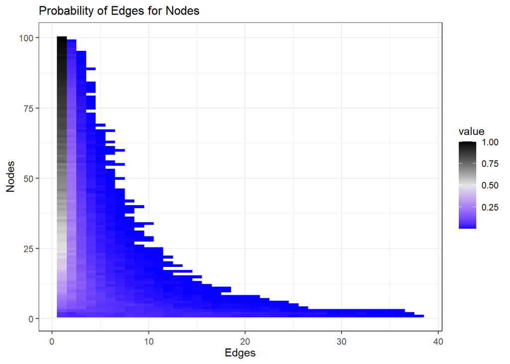

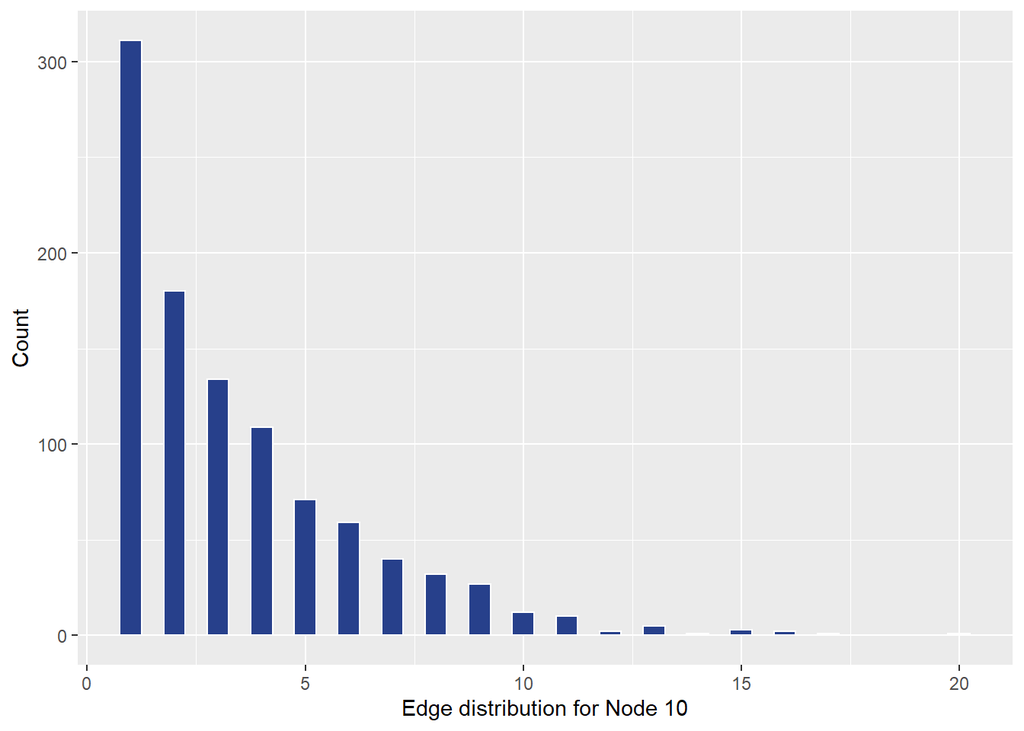

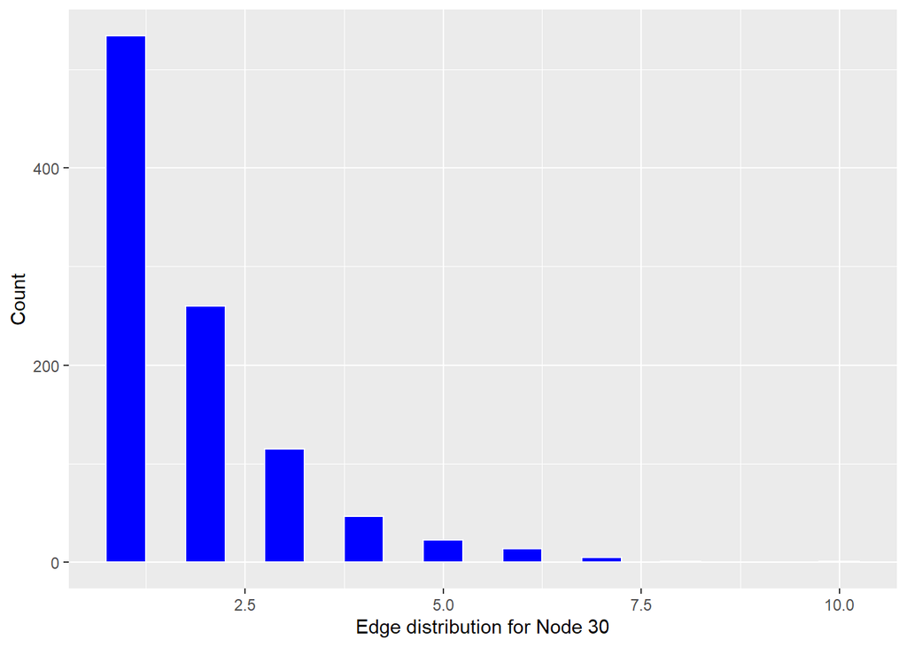

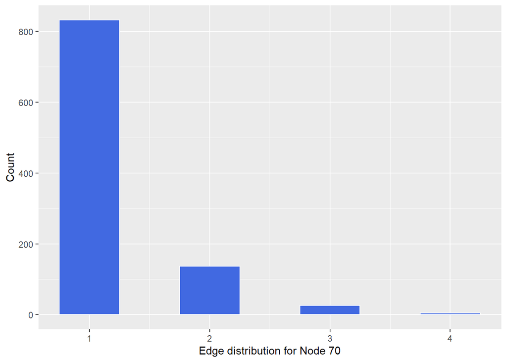

- It can be clearly seen that the edge distribution for nodes is exponential. Let’s see if rate has any changes.

```
## No.of Nodes and rate:
##       1         3        10        20        30        70
##  0.08919015 0.1299883 0.29036 0.4214075 0.5437738 0.8305648
```

- This is same as 15 nodes. But the 20th percentile of 15 nodes i,e; 3 nodes has rate of 0.3547 and same 20th percentile of 100 nodes i.e; 20 nodes has rate of 0.4214. There is a slight increase in rate, this means there is a chance that it deteriorates faster to 0.

### National Nutrient Database

The nndb Dataset is taken and visualized.

| ID | FoodGroup | ShortDescrip | Descrip | CommonName | MfgName | ScientificName | Energy_kcal | Protein_g | Fat_g | Carb_g | Sugar_g |
| --- | --- | --- | --- | --- | --- | --- | --- | --- | --- | --- | --- |
| 1001 | Dairy and Egg Products | BUTTER,WITH SALT | Butter, salted |  |  |  | 717 | 0.85 | 81.11 | 0.06 | 0.06 |
| 1002 | Dairy and Egg Products | BUTTER,WHIPPED,WITH SALT | Butter, whipped, with salt |  |  |  | 717 | 0.85 | 81.11 | 0.06 | 0.06 |
| 1003 | Dairy and Egg Products | BUTTER OIL,ANHYDROUS | Butter oil, anhydrous |  |  |  | 876 | 0.28 | 99.48 | 0.00 | 0.00 |
| 1004 | Dairy and Egg Products | CHEESE,BLUE | Cheese, blue |  |  |  | 353 | 21.40 | 28.74 | 2.34 | 0.50 |
| 1005 | Dairy and Egg Products | CHEESE,BRICK | Cheese, brick |  |  |  | 371 | 23.24 | 29.68 | 2.79 | 0.51 |
| 1006 | Dairy and Egg Products | CHEESE,BRIE | Cheese, brie |  |  |  | 334 | 20.75 | 27.68 | 0.45 | 0.45 |

#### Data representation

- The Data represents the Food compositions with description about each nutrient and what they contain and It also has other attributes like common name, fibre content, protiens, vitamins etc.USRDA - US recommended dietary allowance.
- The USDA National Nutrient Database is the major source of food composition data in the United States.
- It was published by Nutrient Data Laboratory, Beltsville Human Nutrition Research Center, ARS, USDA.

#### Exploring the Data and data types.

```
## 'data.frame':    8618 obs. of  45 variables:
##  $ ID              : int  1001 1002 1003 1004 1005 1006 1007 1008 1009 1010 ...
##  $ FoodGroup       : chr  "Dairy and Egg Products" "Dairy and Egg Products" "Dairy and Egg Products" "Dairy and Egg Products" ...
##  $ ShortDescrip    : chr  "BUTTER,WITH SALT" "BUTTER,WHIPPED,WITH SALT" "BUTTER OIL,ANHYDROUS" "CHEESE,BLUE" ...
##  $ Descrip         : chr  "Butter, salted" "Butter, whipped, with salt" "Butter oil, anhydrous" "Cheese, blue" ...
##  $ CommonName      : chr  "" "" "" "" ...
##  $ MfgName         : chr  "" "" "" "" ...
##  $ ScientificName  : chr  "" "" "" "" ...
##  $ Energy_kcal     : num  717 717 876 353 371 334 300 376 406 387 ...
##  $ Protein_g       : num  0.85 0.85 0.28 21.4 23.24 ...
##  $ Fat_g           : num  81.1 81.1 99.5 28.7 29.7 ...
##  $ Carb_g          : num  0.06 0.06 0 2.34 2.79 0.45 0.46 3.06 1.33 4.78 ...
##  $ Sugar_g         : num  0.06 0.06 0 0.5 0.51 0.45 0.46 0 0.28 0 ...
##  $ Fiber_g         : num  0 0 0 0 0 0 0 0 0 0 ...
##  $ VitA_mcg        : num  684 684 840 198 292 174 241 271 263 233 ...
```

[output cut: 31 more lines]

The following shows the whole summary of the dataset like Means, medians, counts etc.

```
##        ID         FoodGroup         ShortDescrip         Descrip
##  Min.   : 1001   Length:8618        Length:8618        Length:8618
##  1st Qu.: 8695   Class :character   Class :character   Class :character
##  Median :14273   Mode  :character   Mode  :character   Mode  :character
##  Mean   :15468
##  3rd Qu.:20051
##  Max.   :93600
##   CommonName          MfgName          ScientificName      Energy_kcal
##  Length:8618        Length:8618        Length:8618        Min.   :  0.0
##  Class :character   Class :character   Class :character   1st Qu.: 93.0
##  Mode  :character   Mode  :character   Mode  :character   Median :191.0
##                                                           Mean   :226.4
##                                                           3rd Qu.:336.0
##                                                           Max.   :902.0
##    Protein_g          Fat_g              Carb_g           Sugar_g
##  Min.   : 0.000   Min.   :  0.0000   Min.   :  0.000   Min.   : 0.00
##  1st Qu.: 2.470   1st Qu.:  0.9925   1st Qu.:  0.040   1st Qu.: 0.00
##  Median : 8.285   Median :  5.2350   Median :  8.945   Median : 0.37
##  Mean   :11.524   Mean   : 10.6470   Mean   : 21.819   Mean   : 6.56
##  3rd Qu.:19.977   3rd Qu.: 13.9000   3rd Qu.: 32.900   3rd Qu.: 5.30
##  Max.   :88.320   Max.   :100.0000   Max.   :100.000   Max.   :99.80
##     Fiber_g          VitA_mcg           VitB6_mg          VitB12_mcg
##  Min.   : 0.000   Min.   :    0.00   Min.   : 0.00000   Min.   : 0.000
##  1st Qu.: 0.000   1st Qu.:    0.00   1st Qu.: 0.03425   1st Qu.: 0.000
##  Median : 0.300   Median :    1.50   Median : 0.12000   Median : 0.080
##  Mean   : 2.023   Mean   :   93.97   Mean   : 0.26437   Mean   : 1.225
##  3rd Qu.: 2.400   3rd Qu.:   21.00   3rd Qu.: 0.35500   3rd Qu.: 1.298
##  Max.   :79.000   Max.   :30000.00   Max.   :12.00000   Max.   :98.890
##     VitC_mg            VitE_mg           Folate_mcg        Niacin_mg
##  Min.   :   0.000   Min.   :  0.0000   Min.   :   0.00   Min.   :  0.000
##  1st Qu.:   0.000   1st Qu.:  0.0000   1st Qu.:   0.00   1st Qu.:  0.382
##  Median :   0.000   Median :  0.1100   Median :   7.00   Median :  2.100
##  Mean   :   7.925   Mean   :  0.8723   Mean   :  50.31   Mean   :  3.412
##  3rd Qu.:   2.500   3rd Qu.:  0.4500   3rd Qu.:  25.00   3rd Qu.:  5.029
##  Max.   :2400.000   Max.   :149.4000   Max.   :5881.00   Max.   :127.500
##  Riboflavin_mg       Thiamin_mg        Calcium_mg        Copper_mcg
##  Min.   : 0.0000   Min.   : 0.0000   Min.   :   0.00   Min.   : 0.0000
##  1st Qu.: 0.0460   1st Qu.: 0.0300   1st Qu.:   9.00   1st Qu.: 0.0300
##  Median : 0.1500   Median : 0.0775   Median :  19.00   Median : 0.0790
##  Mean   : 0.2372   Mean   : 0.2099   Mean   :  73.41   Mean   : 0.1722
```

[output cut: 29 more lines]

```
##  Max.   :7.96875   Max.   :13.46154   Max.   :19.47917   Max.   :6.13667
##   Copper_USRDA       Magnesium_USRDA   Phosphorus_USRDA   Selenium_USRDA
##  Min.   :0.000e+00   Min.   :0.00000   Min.   : 0.00000   Min.   : 0.00000
##  1st Qu.:3.333e-05   1st Qu.:0.02381   1st Qu.: 0.05286   1st Qu.: 0.00182
##  Median :8.778e-05   Median :0.04762   Median : 0.19000   Median : 0.07091
##  Mean   :1.913e-04   Mean   :0.07797   Mean   : 0.22284   Mean   : 0.22936
##  3rd Qu.:1.608e-04   3rd Qu.:0.06905   3rd Qu.: 0.30857   3rd Qu.: 0.38727
##  Max.   :1.672e-02   Max.   :1.85952   Max.   :14.16857   Max.   :34.85455
##    Zinc_USRDA
##  Min.   :0.00000
##  1st Qu.:0.02091
##  Median :0.07682
##  Mean   :0.17911
##  3rd Qu.:0.24546
##  Max.   :8.26818
```

Let’s explore the data by making some plots.

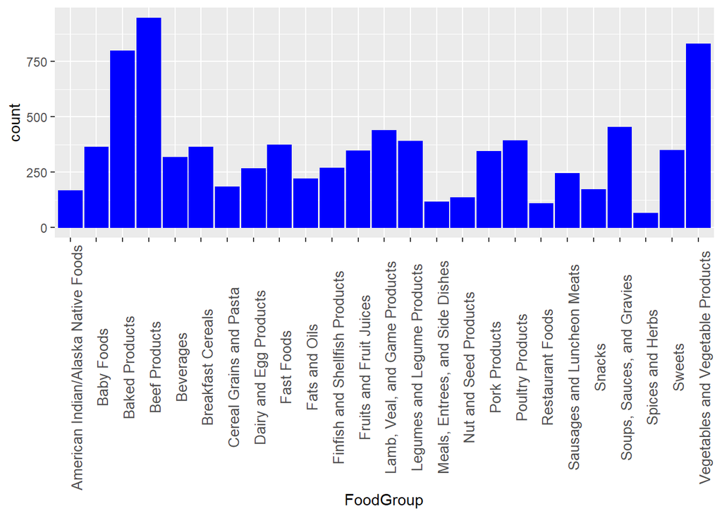

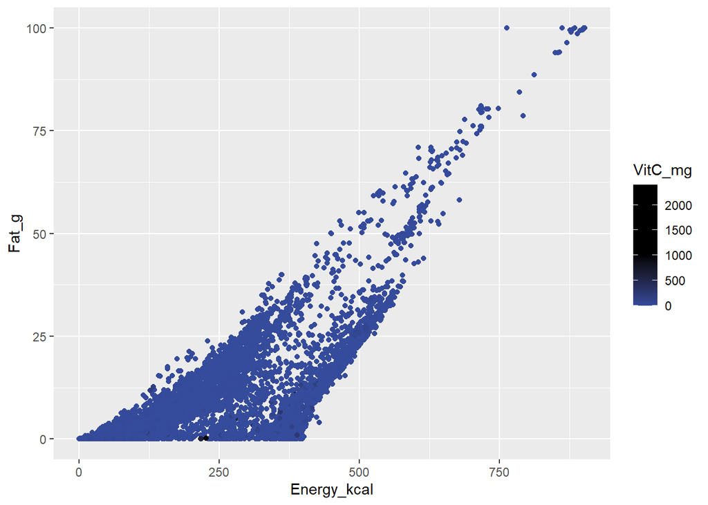

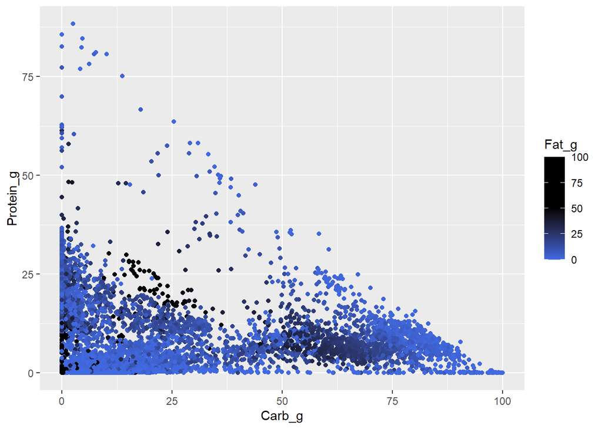

#### Correlation Matrix.

The Matrix is very huge, since it has many columns, The following is the correlation matrix for some data.

|  | Energy_kcal | Protein_g | Fat_g | Carb_g | Sugar_g | Fiber_g | VitA_mcg | VitB6_mg | VitB12_mcg | VitC_mg | VitE_mg | Folate_mcg | Niacin_mg | Riboflavin_mg | Thiamin_mg | Calcium_mg | Copper_mcg | Iron_mg | Magnesium_mg | Manganese_mg | Phosphorus_mg | Selenium_mcg | Zinc_mg | VitA_USRDA | VitB6_USRDA | VitB12_USRDA | VitC_USRDA | VitE_USRDA | Folate_USRDA | … |
| --- | --- | --- | --- | --- | --- | --- | --- | --- | --- | --- | --- | --- | --- | --- | --- | --- | --- | --- | --- | --- | --- | --- | --- | --- | --- | --- | --- | --- | --- | --- |
| Energy_kcal | 1.00 | 0.11 | 0.81 | 0.49 | 0.31 | 0.20 | 0.03 | 0.12 | -0.01 | -0.03 | 0.30 | 0.15 | 0.17 | 0.16 | 0.19 | 0.12 | 0.10 | 0.20 | 0.26 | 0.04 | 0.20 | 0.06 | 0.11 | 0.03 | 0.12 | -0.01 | -0.03 | 0.30 | 0.15 | … |
| Protein_g | 0.11 | 1.00 | 0.05 | -0.30 | -0.27 | -0.07 | 0.03 | 0.23 | 0.25 | -0.07 | -0.03 | 0.01 | 0.38 | 0.20 | 0.10 | 0.05 | 0.16 | 0.13 | 0.22 | 0.04 | 0.44 | 0.38 | 0.42 | 0.03 | 0.23 | 0.25 | -0.07 | -0.03 | 0.01 | … |
| Fat_g | 0.81 | 0.05 | 1.00 | -0.05 | 0.00 | -0.03 | 0.02 | -0.05 | -0.02 | -0.06 | 0.34 | -0.06 | -0.02 | -0.04 | -0.01 | 0.02 | 0.04 | -0.04 | 0.07 | 0.00 | 0.07 | 0.04 | 0.03 | 0.02 | -0.05 | -0.02 | -0.06 | 0.34 | -0.06 | … |
| Carb_g | 0.49 | -0.30 | -0.05 | 1.00 | 0.62 | 0.46 | 0.00 | 0.20 | -0.09 | 0.08 | 0.07 | 0.33 | 0.17 | 0.23 | 0.28 | 0.19 | 0.06 | 0.35 | 0.29 | 0.06 | 0.07 | -0.11 | -0.01 | 0.00 | 0.20 | -0.09 | 0.08 | 0.07 | 0.33 | … |
| Sugar_g | 0.31 | -0.27 | 0.00 | 0.62 | 1.00 | 0.12 | 0.01 | 0.09 | -0.05 | 0.06 | 0.07 | 0.16 | 0.03 | 0.13 | 0.10 | 0.13 | -0.01 | 0.12 | 0.04 | 0.01 | -0.05 | -0.12 | -0.02 | 0.01 | 0.09 | -0.05 | 0.06 | 0.07 | 0.16 | … |
| Fiber_g | 0.20 | -0.07 | -0.03 | 0.46 | 0.12 | 1.00 | 0.01 | 0.24 | -0.05 | 0.08 | 0.16 | 0.25 | 0.14 | 0.16 | 0.21 | 0.23 | 0.19 | 0.39 | 0.54 | 0.10 | 0.16 | -0.04 | 0.09 | 0.01 | 0.24 | -0.05 | 0.08 | 0.16 | 0.25 | … |
| VitA_mcg | 0.03 | 0.03 | 0.02 | 0.00 | 0.01 | 0.01 | 1.00 | 0.14 | 0.58 | 0.11 | 0.04 | 0.11 | 0.15 | 0.33 | 0.05 | 0.03 | 0.57 | 0.10 | 0.02 | 0.37 | 0.06 | 0.05 | 0.07 | 1.00 | 0.14 | 0.58 | 0.11 | 0.04 | 0.11 | … |
| VitB6_mg | 0.12 | 0.23 | -0.05 | 0.20 | 0.09 | 0.24 | 0.14 | 1.00 | 0.26 | 0.27 | 0.29 | 0.55 | 0.71 | 0.58 | 0.42 | 0.18 | 0.12 | 0.48 | 0.29 | 0.07 | 0.21 | 0.11 | 0.45 | 0.14 | 1.00 | 0.26 | 0.27 | 0.29 | 0.55 | … |
| VitB12_mcg | -0.01 | 0.25 | -0.02 | -0.09 | -0.05 | -0.05 | 0.58 | 0.26 | 1.00 | 0.01 | 0.06 | 0.16 | 0.28 | 0.44 | 0.10 | 0.01 | 0.57 | 0.18 | 0.00 | 0.24 | 0.15 | 0.22 | 0.30 | 0.58 | 0.26 | 1.00 | 0.01 | 0.06 | 0.16 | … |
| VitC_mg | -0.03 | -0.07 | -0.06 | 0.08 | 0.06 | 0.08 | 0.11 | 0.27 | 0.01 | 1.00 | 0.07 | 0.07 | 0.21 | 0.23 | 0.06 | 0.11 | 0.03 | 0.07 | 0.12 | 0.02 | 0.01 | -0.04 | 0.02 | 0.11 | 0.27 | 0.01 | 1.00 | 0.07 | 0.07 | … |
| VitE_mg | 0.30 | -0.03 | 0.34 | 0.07 | 0.07 | 0.16 | 0.04 | 0.29 | 0.06 | 0.07 | 1.00 | 0.18 | 0.20 | 0.16 | 0.12 | 0.11 | 0.07 | 0.16 | 0.20 | 0.10 | 0.07 | 0.02 | 0.17 | 0.04 | 0.29 | 0.06 | 0.07 | 1.00 | 0.18 | … |
| Folate_mcg | 0.15 | 0.01 | -0.06 | 0.33 | 0.16 | 0.25 | 0.11 | 0.55 | 0.16 | 0.07 | 0.18 | 1.00 | 0.54 | 0.57 | 0.54 | 0.15 | 0.12 | 0.47 | 0.24 | 0.06 | 0.12 | 0.03 | 0.32 | 0.11 | 0.55 | 0.16 | 0.07 | 0.18 | 1.00 | … |
| Niacin_mg | 0.17 | 0.38 | -0.02 | 0.17 | 0.03 | 0.14 | 0.15 | 0.71 | 0.28 | 0.21 | 0.20 | 0.54 | 1.00 | 0.75 | 0.60 | 0.13 | 0.14 | 0.50 | 0.27 | 0.10 | 0.26 | 0.18 | 0.47 | 0.15 | 0.71 | 0.28 | 0.21 | 0.20 | 0.54 | … |
| Riboflavin_mg | 0.16 | 0.20 | -0.04 | 0.23 | 0.13 | 0.16 | 0.33 | 0.58 | 0.44 | 0.23 | 0.16 | 0.57 | 0.75 | 1.00 | 0.63 | 0.22 | 0.30 | 0.51 | 0.23 | 0.11 | 0.22 | 0.14 | 0.37 | 0.33 | 0.58 | 0.44 | 0.23 | 0.16 | 0.57 | … |
| Thiamin_mg | 0.19 | 0.10 | -0.01 | 0.28 | 0.10 | 0.21 | 0.05 | 0.42 | 0.10 | 0.06 | 0.12 | 0.54 | 0.60 | 0.63 | 1.00 | 0.14 | 0.10 | 0.40 | 0.24 | 0.05 | 0.17 | 0.06 | 0.25 | 0.05 | 0.42 | 0.10 | 0.06 | 0.12 | 0.54 | … |
| Calcium_mg | 0.12 | 0.05 | 0.02 | 0.19 | 0.13 | 0.23 | 0.03 | 0.18 | 0.01 | 0.11 | 0.11 | 0.15 | 0.13 | 0.22 | 0.14 | 1.00 | 0.08 | 0.35 | 0.31 | 0.07 | 0.57 | 0.01 | 0.14 | 0.03 | 0.18 | 0.01 | 0.11 | 0.11 | 0.15 | … |
| Copper_mcg | 0.10 | 0.16 | 0.04 | 0.06 | -0.01 | 0.19 | 0.57 | 0.12 | 0.57 | 0.03 | 0.07 | 0.12 | 0.14 | 0.30 | 0.10 | 0.08 | 1.00 | 0.18 | 0.34 | 0.17 | 0.22 | 0.13 | 0.26 | 0.57 | 0.12 | 0.57 | 0.03 | 0.07 | 0.12 | … |
| Iron_mg | 0.20 | 0.13 | -0.04 | 0.35 | 0.12 | 0.39 | 0.10 | 0.48 | 0.18 | 0.07 | 0.16 | 0.47 | 0.50 | 0.51 | 0.40 | 0.35 | 0.18 | 1.00 | 0.40 | 0.09 | 0.22 | 0.06 | 0.38 | 0.10 | 0.48 | 0.18 | 0.07 | 0.16 | 0.47 | … |
| Magnesium_mg | 0.26 | 0.22 | 0.07 | 0.29 | 0.04 | 0.54 | 0.02 | 0.29 | 0.00 | 0.12 | 0.20 | 0.24 | 0.27 | 0.23 | 0.24 | 0.31 | 0.34 | 0.40 | 1.00 | 0.18 | 0.43 | 0.13 | 0.26 | 0.02 | 0.29 | 0.00 | 0.12 | 0.20 | 0.24 | … |
| Manganese_mg | 0.04 | 0.04 | 0.00 | 0.06 | 0.01 | 0.10 | 0.37 | 0.07 | 0.24 | 0.02 | 0.10 | 0.06 | 0.10 | 0.11 | 0.05 | 0.07 | 0.17 | 0.09 | 0.18 | 1.00 | 0.08 | 0.02 | 0.07 | 0.37 | 0.07 | 0.24 | 0.02 | 0.10 | 0.06 | … |
| Phosphorus_mg | 0.20 | 0.44 | 0.07 | 0.07 | -0.05 | 0.16 | 0.06 | 0.21 | 0.15 | 0.01 | 0.07 | 0.12 | 0.26 | 0.22 | 0.17 | 0.57 | 0.22 | 0.22 | 0.43 | 0.08 | 1.00 | 0.22 | 0.27 | 0.06 | 0.21 | 0.15 | 0.01 | 0.07 | 0.12 | … |
| Selenium_mcg | 0.06 | 0.38 | 0.04 | -0.11 | -0.12 | -0.04 | 0.05 | 0.11 | 0.22 | -0.04 | 0.02 | 0.03 | 0.18 | 0.14 | 0.06 | 0.01 | 0.13 | 0.06 | 0.13 | 0.02 | 0.22 | 1.00 | 0.21 | 0.05 | 0.11 | 0.22 | -0.04 | 0.02 | 0.03 | … |
| Zinc_mg | 0.11 | 0.42 | 0.03 | -0.01 | -0.02 | 0.09 | 0.07 | 0.45 | 0.30 | 0.02 | 0.17 | 0.32 | 0.47 | 0.37 | 0.25 | 0.14 | 0.26 | 0.38 | 0.26 | 0.07 | 0.27 | 0.21 | 1.00 | 0.07 | 0.45 | 0.30 | 0.02 | 0.17 | 0.32 | … |
| VitA_USRDA | 0.03 | 0.03 | 0.02 | 0.00 | 0.01 | 0.01 | 1.00 | 0.14 | 0.58 | 0.11 | 0.04 | 0.11 | 0.15 | 0.33 | 0.05 | 0.03 | 0.57 | 0.10 | 0.02 | 0.37 | 0.06 | 0.05 | 0.07 | 1.00 | 0.14 | 0.58 | 0.11 | 0.04 | 0.11 | … |
| VitB6_USRDA | 0.12 | 0.23 | -0.05 | 0.20 | 0.09 | 0.24 | 0.14 | 1.00 | 0.26 | 0.27 | 0.29 | 0.55 | 0.71 | 0.58 | 0.42 | 0.18 | 0.12 | 0.48 | 0.29 | 0.07 | 0.21 | 0.11 | 0.45 | 0.14 | 1.00 | 0.26 | 0.27 | 0.29 | 0.55 | … |
| VitB12_USRDA | -0.01 | 0.25 | -0.02 | -0.09 | -0.05 | -0.05 | 0.58 | 0.26 | 1.00 | 0.01 | 0.06 | 0.16 | 0.28 | 0.44 | 0.10 | 0.01 | 0.57 | 0.18 | 0.00 | 0.24 | 0.15 | 0.22 | 0.30 | 0.58 | 0.26 | 1.00 | 0.01 | 0.06 | 0.16 | … |
| VitC_USRDA | -0.03 | -0.07 | -0.06 | 0.08 | 0.06 | 0.08 | 0.11 | 0.27 | 0.01 | 1.00 | 0.07 | 0.07 | 0.21 | 0.23 | 0.06 | 0.11 | 0.03 | 0.07 | 0.12 | 0.02 | 0.01 | -0.04 | 0.02 | 0.11 | 0.27 | 0.01 | 1.00 | 0.07 | 0.07 | … |
| VitE_USRDA | 0.30 | -0.03 | 0.34 | 0.07 | 0.07 | 0.16 | 0.04 | 0.29 | 0.06 | 0.07 | 1.00 | 0.18 | 0.20 | 0.16 | 0.12 | 0.11 | 0.07 | 0.16 | 0.20 | 0.10 | 0.07 | 0.02 | 0.17 | 0.04 | 0.29 | 0.06 | 0.07 | 1.00 | 0.18 | … |
| Folate_USRDA | 0.15 | 0.01 | -0.06 | 0.33 | 0.16 | 0.25 | 0.11 | 0.55 | 0.16 | 0.07 | 0.18 | 1.00 | 0.54 | 0.57 | 0.54 | 0.15 | 0.12 | 0.47 | 0.24 | 0.06 | 0.12 | 0.03 | 0.32 | 0.11 | 0.55 | 0.16 | 0.07 | 0.18 | 1.00 | … |
| Niacin_USRDA | 0.17 | 0.38 | -0.02 | 0.17 | 0.03 | 0.14 | 0.15 | 0.71 | 0.28 | 0.21 | 0.20 | 0.54 | 1.00 | 0.75 | 0.60 | 0.13 | 0.14 | 0.50 | 0.27 | 0.10 | 0.26 | 0.18 | 0.47 | 0.15 | 0.71 | 0.28 | 0.21 | 0.20 | 0.54 | … |
| Riboflavin_USRDA | 0.16 | 0.20 | -0.04 | 0.23 | 0.13 | 0.16 | 0.33 | 0.58 | 0.44 | 0.23 | 0.16 | 0.57 | 0.75 | 1.00 | 0.63 | 0.22 | 0.30 | 0.51 | 0.23 | 0.11 | 0.22 | 0.14 | 0.37 | 0.33 | 0.58 | 0.44 | 0.23 | 0.16 | 0.57 | … |
| Thiamin_USRDA | 0.19 | 0.10 | -0.01 | 0.28 | 0.10 | 0.21 | 0.05 | 0.42 | 0.10 | 0.06 | 0.12 | 0.54 | 0.60 | 0.63 | 1.00 | 0.14 | 0.10 | 0.40 | 0.24 | 0.05 | 0.17 | 0.06 | 0.25 | 0.05 | 0.42 | 0.10 | 0.06 | 0.12 | 0.54 | … |
| Calcium_USRDA | 0.12 | 0.05 | 0.02 | 0.19 | 0.13 | 0.23 | 0.03 | 0.18 | 0.01 | 0.11 | 0.11 | 0.15 | 0.13 | 0.22 | 0.14 | 1.00 | 0.08 | 0.35 | 0.31 | 0.07 | 0.57 | 0.01 | 0.14 | 0.03 | 0.18 | 0.01 | 0.11 | 0.11 | 0.15 | … |
| Copper_USRDA | 0.10 | 0.16 | 0.04 | 0.06 | -0.01 | 0.19 | 0.57 | 0.12 | 0.57 | 0.03 | 0.07 | 0.12 | 0.14 | 0.30 | 0.10 | 0.08 | 1.00 | 0.18 | 0.34 | 0.17 | 0.22 | 0.13 | 0.26 | 0.57 | 0.12 | 0.57 | 0.03 | 0.07 | 0.12 | … |
| Magnesium_USRDA | 0.26 | 0.22 | 0.07 | 0.29 | 0.04 | 0.54 | 0.02 | 0.29 | 0.00 | 0.12 | 0.20 | 0.24 | 0.27 | 0.23 | 0.24 | 0.31 | 0.34 | 0.40 | 1.00 | 0.18 | 0.43 | 0.13 | 0.26 | 0.02 | 0.29 | 0.00 | 0.12 | 0.20 | 0.24 | … |
| Phosphorus_USRDA | 0.20 | 0.44 | 0.07 | 0.07 | -0.05 | 0.16 | 0.06 | 0.21 | 0.15 | 0.01 | 0.07 | 0.12 | 0.26 | 0.22 | 0.17 | 0.57 | 0.22 | 0.22 | 0.43 | 0.08 | 1.00 | 0.22 | 0.27 | 0.06 | 0.21 | 0.15 | 0.01 | 0.07 | 0.12 | … |
| Selenium_USRDA | 0.06 | 0.38 | 0.04 | -0.11 | -0.12 | -0.04 | 0.05 | 0.11 | 0.22 | -0.04 | 0.02 | 0.03 | 0.18 | 0.14 | 0.06 | 0.01 | 0.13 | 0.06 | 0.13 | 0.02 | 0.22 | 1.00 | 0.21 | 0.05 | 0.11 | 0.22 | -0.04 | 0.02 | 0.03 | … |
| Zinc_USRDA | 0.11 | 0.42 | 0.03 | -0.01 | -0.02 | 0.09 | 0.07 | 0.45 | 0.30 | 0.02 | 0.17 | 0.32 | 0.47 | 0.37 | 0.25 | 0.14 | 0.26 | 0.38 | 0.26 | 0.07 | 0.27 | 0.21 | 1.00 | 0.07 | 0.45 | 0.30 | 0.02 | 0.17 | 0.32 | … |

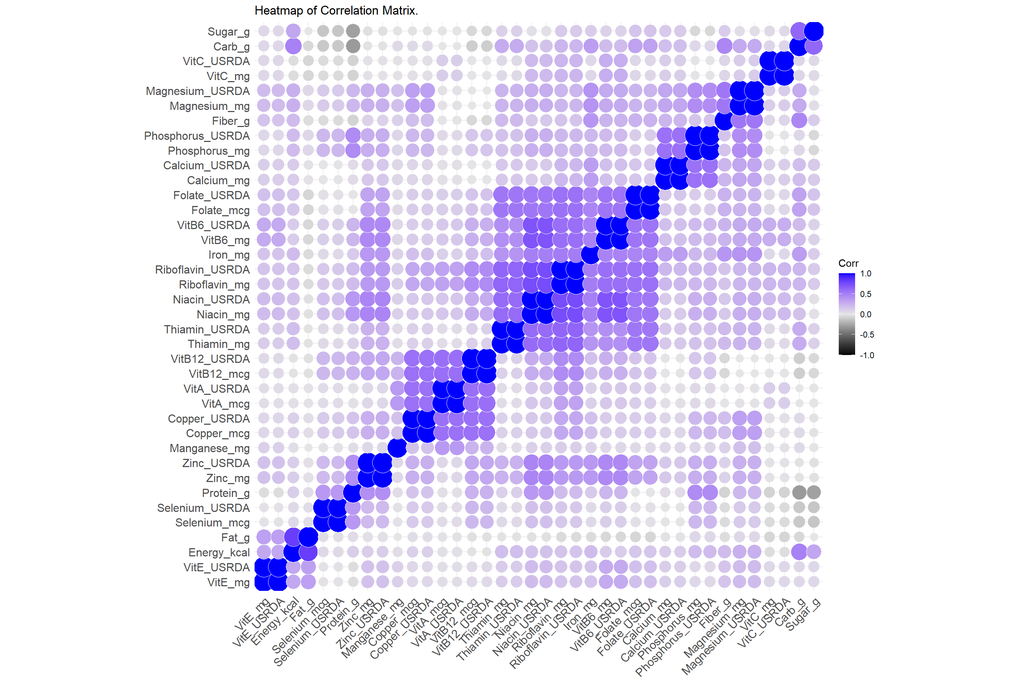